# HubertBanieckiPd2

Hubert Baniecki

18 03 2019

https://cran.r-project.org/web/packages/vtreat/vignettes/vtreatOverfit.html  
https://cran.r-project.org/web/packages/vtreat/vignettes/vtreatCrossFrames.html

# 1 Przygotowanie danych

Wezmę dane z *compass*. Wybrałem w miarę istotne kolumny oraz usunąłem niepotrzebne wiersze.

```r
enc <- guess_encoding("cox-violent-parsed.csv", n_max = 10000)[[1]]
dane <- as.data.frame(read_csv("cox-violent-parsed.csv", locale = locale(encoding = enc[1])))

df <- select(dane, name, sex, age, age_cat, race, juv_fel_count, juv_misd_count, juv_other_count, priors_count, c_charge_degree, c_charge_desc, is_recid)

df <- df %>% distinct() %>% filter(is_recid!=-1) %>% filter(c_charge_degree != "O")
df[df == ""] <- NA
df <- na.omit(df)

d <- as.data.frame(unclass(df))
d$is_recid <- as.factor(d$is_recid)

d$rgroup <- sample(c("cal", "train", "test"), nrow(d), replace=TRUE, prob=c(0.3, 0.4, 0.2))
```

# 2 Model przed kodowaniem

Sprawdzam działanie modelu przed kodowaniem kolumn.

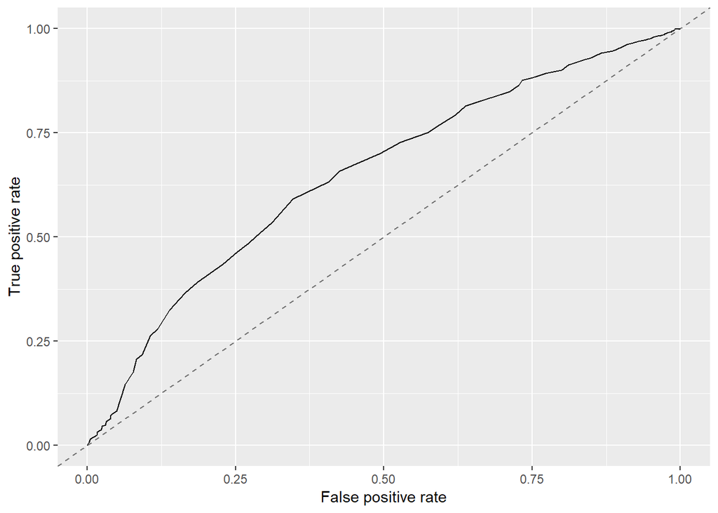

```r
df1 <- select(d, -name)
dTrain0 <- df1[df1$rgroup=='train', -12]
dTest0 <- df1[df1$rgroup=='test', -12]

classif_task <- makeClassifTask(id = "task", data = dTrain0, target = "is_recid")
classif_lrn <- makeLearner("classif.gbm", predict.type = "prob", par.vals = list(distribution = "bernoulli"))

m0 <- train(classif_lrn, classif_task)
p0 <- predict(m0, newdata = dTest0, type='response')
temp0 <-  generateThreshVsPerfData(p0, measures = list(fpr, tpr, mmce))

plotROCCurves(temp0)
```

```r
performance(p0, list(auc,acc))
```

```
##       auc       acc
## 0.6500794 0.6688510
```

# 3 Model po kodowaniu

Uzywając `vtreat::designTreatmentsC` zastosuję metody kodowania zmiennych takie jak Impact i One-Hot Encoding na kolumnach kategorycznych. Ogólnie `vtreat` automatycznie wybiera najpopularniejsze poziomy zmiennych kategorycznych i tylko z nich robi kolumny do One-Hot Encoding.  
Żeby poradzić sobie z zbyt dużą liczbą unikalnych poziomów można wybrać ileś najpopularniejszych, a resztę zakwalifikować jako inne. Suma liczności innych poziomów powinna być mniejsza niż liczność ostatniego konkretnego.  
Do tego zadania można użyć biblioteki `forecats`. Zastosuję groupowanie na kolumnie `charge_desc` i `charge_degree` przed kodowaniem. Zmniejszy to też szansę na wystąpienie dodatkowych poziomów w zbiorze testowym.

## 3.1 Jak nie robić

**Nie przygotowywać kodowania na danych testowych.**  
**Najlepiej nie używać tych samych danych do przygotowania kodowania i uczenia modelu.**  
Wynik modelu, w którym przygotowano kodowanie na całych danych:

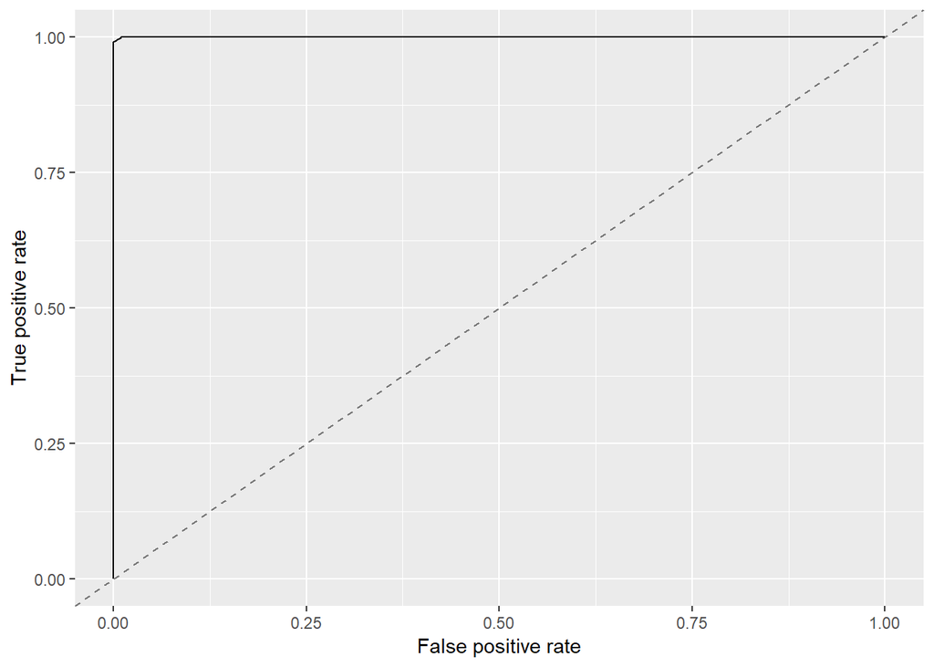

```r
d$c_charge_desc <- fct_lump(d$c_charge_desc, 5)
d$c_charge_degree <- fct_lump(d$c_charge_degree, 5)

dCal <- d[d$rgroup == 'cal', -13]
dTrain <- d[d$rgroup=='train', -13]
dTest <- d[d$rgroup=='test', -13]

treatments <- designTreatmentsC(dTrain, varlist = colnames(dTrain)[-12], outcomename='is_recid', outcometarget=1, verbose=FALSE)
dTrainTreated <- prepare(treatments, dTrain)

classif_task <- makeClassifTask(id = "task", data = dTrainTreated[1:3500,], target = "is_recid")
classif_lrn <- makeLearner("classif.gbm", predict.type = "prob", par.vals = list(distribution = "bernoulli"))

m1 <- train(classif_lrn, classif_task)
p1 <- predict(m1, newdata = dTrainTreated[3501:4400,], type='response')
temp <-  generateThreshVsPerfData(p1, measures = list(fpr, tpr, mmce))

plotROCCurves(temp)
```

```r
performance(p1, list(auc,acc))
```

```
##       auc       acc
## 0.9999615 0.9966667
```

Sprawdzenie modelu na osobnym zbiorze, żeby przekonać się, że wynik nic nie znaczy:

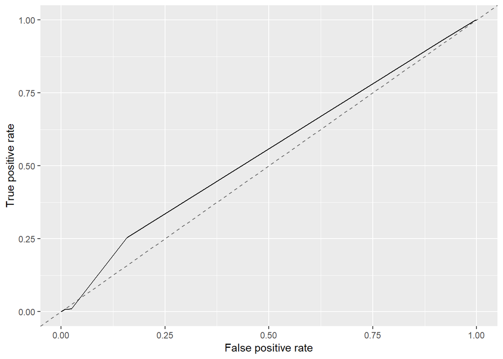

```r
dTestTreated <- prepare(treatments, dTest)

p2 <- predict(m1, newdata = dTestTreated, type='response')
temp2 <-  generateThreshVsPerfData(p2, measures = list(fpr, tpr, mmce))

plotROCCurves(temp2)
```

```r
performance(p2, list(auc,acc))
```

```
##       auc       acc
## 0.5449176 0.4504150
```

## 3.2 Jak robić

**Użyć innych danych do przygotowania kodowania i uczenia. Wykorzystać do tego zbiór kalibracyjny.**  
Dzielimy dane na trzy zbiory. Przygotowujemy kodowanie na podstawie jednego z nich.  
Stosujemy je na zbiorze uczącym oraz testowym.  
**Po takim zabiegu model wypadł trochę lepiej od tego bez kodowania**.

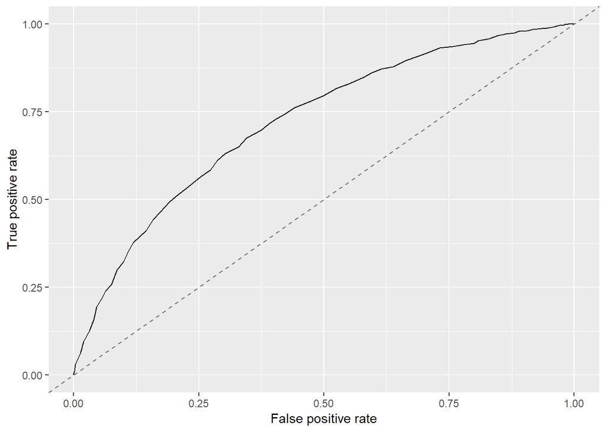

```r
pruneSig <- 1/ncol(dTrain)

treatments2 <- designTreatmentsC(dCal, varlist = colnames(dCal)[-12], outcomename='is_recid', outcometarget=1, verbose=FALSE)
dTrainTreated2 <- prepare(treatments2, dTrain, pruneSig=pruneSig)
dTestTreated2 <- prepare(treatments2, dTest, pruneSig=pruneSig)

classif_task3 <- makeClassifTask(id = "task", data = dTrainTreated2, target = "is_recid")

m3 <- train(classif_lrn, classif_task3)
p3 <- predict(m3, newdata = dTestTreated2, type='response')
temp3 <-  generateThreshVsPerfData(p3, measures = list(fpr, tpr, mmce))

plotROCCurves(temp3)
```

```r
performance(p3, list(auc,acc))
```

```
##       auc       acc
## 0.7220835 0.7099170
```

Poniżej sprawdzamy działanie modelu na zbiorze uczącym. **Dzięki zbiorowi kalibracyjnemu ograniczyliśmy overfitting.**

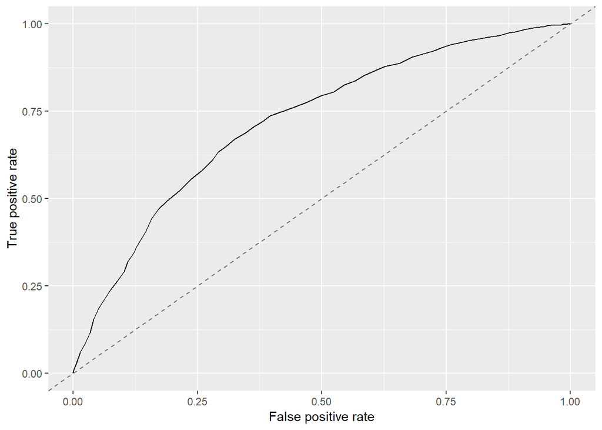

```r
p4 <- predict(m3, newdata = dTrainTreated2, type='response')
temp4 <-  generateThreshVsPerfData(p4, measures = list(fpr, tpr, mmce))

plotROCCurves(temp4)
```

```r
performance(p4, list(auc,acc))
```

```
##       auc       acc
## 0.7215227 0.7017275
```

# 4 Brakujące poziomy

Grupowanie zmiennych kategorycznych pomaga w tym problemie, jednak nie zawsze w stu procentach skutecznie. Kodowanie w `vtreat` radzi sobie automatycznie z nowymi poziomami w zbiorze, który kodujemy. W zależności od sytuacji wybiera jedną z wielu metod. Może to być wstawienie neutralnych wartości w miejsce niewiadomej, takich jak uśredniona wartość z kolumny lub po prostu zero. Innym sposobem jest zakwalifikowanie wszystkich nowych wartości jako osobna klasa i potraktowanie ich w jeden określony sposób.